# 01 Muestreo Aleatorio Simple

FES Acatlán

febrero de 2022

## Muestreo Aleatorio Simple

Este esquema de muestreo es el más usado cuando se tiene un marco de muestreo que especifique la manera de identificar cada unidad en la población.

De una población de $N$ unidades, se selecciona una muestra de tal manera que todas las unidades de la población tienen la misma probabilidad de ser seleccionadas. Como consecuencia, la probabilidad de que un elemento esté en la muestra es $\frac{n}{N}$, suele denotarse por $\pi_{i}$. También se le conoce como probabilidad de inclusión de primer orden.

Al inverso de $\pi_{i}$ se le conoce como **factor de expansión** o peso muestral.

De manera ilustrativa veanlo como una urna donde se selecciona un elemento a la vez hasta tener $n$

```r
urna <- paste("papelito",1:100, sep = " ")
urna
```

```
##   [1] "papelito 1"   "papelito 2"   "papelito 3"   "papelito 4"   "papelito 5"
##   [6] "papelito 6"   "papelito 7"   "papelito 8"   "papelito 9"   "papelito 10"
##  [11] "papelito 11"  "papelito 12"  "papelito 13"  "papelito 14"  "papelito 15"
##  [16] "papelito 16"  "papelito 17"  "papelito 18"  "papelito 19"  "papelito 20"
##  [21] "papelito 21"  "papelito 22"  "papelito 23"  "papelito 24"  "papelito 25"
##  [26] "papelito 26"  "papelito 27"  "papelito 28"  "papelito 29"  "papelito 30"
##  [31] "papelito 31"  "papelito 32"  "papelito 33"  "papelito 34"  "papelito 35"
##  [36] "papelito 36"  "papelito 37"  "papelito 38"  "papelito 39"  "papelito 40"
##  [41] "papelito 41"  "papelito 42"  "papelito 43"  "papelito 44"  "papelito 45"
##  [46] "papelito 46"  "papelito 47"  "papelito 48"  "papelito 49"  "papelito 50"
##  [51] "papelito 51"  "papelito 52"  "papelito 53"  "papelito 54"  "papelito 55"
##  [56] "papelito 56"  "papelito 57"  "papelito 58"  "papelito 59"  "papelito 60"
##  [61] "papelito 61"  "papelito 62"  "papelito 63"  "papelito 64"  "papelito 65"
##  [66] "papelito 66"  "papelito 67"  "papelito 68"  "papelito 69"  "papelito 70"
##  [71] "papelito 71"  "papelito 72"  "papelito 73"  "papelito 74"  "papelito 75"
##  [76] "papelito 76"  "papelito 77"  "papelito 78"  "papelito 79"  "papelito 80"
##  [81] "papelito 81"  "papelito 82"  "papelito 83"  "papelito 84"  "papelito 85"
##  [86] "papelito 86"  "papelito 87"  "papelito 88"  "papelito 89"  "papelito 90"
##  [91] "papelito 91"  "papelito 92"  "papelito 93"  "papelito 94"  "papelito 95"
##  [96] "papelito 96"  "papelito 97"  "papelito 98"  "papelito 99"  "papelito 100"
```

Generamos un número aleatorio entre 1 y el número total de elementos. Esto lo podemos hacer usando un número aleatorio (uniforme entre cero y uno) y transformandolo. si $u$ se distribuye $unif(0,1)$, entonces $c = (b-a)*u + a$ se distribuye $unif(a,b)$

```r
u <- runif(1) # 1 número aleatorio uniforme entre cero y uno
a <- 1
b <- 100

c <- floor((b-a)*u + a)
print(c)
```

```
## [1] 53
```

Extraemos el elemento elegido por el número aleatorio y repetimos el proceso hasta seleccionar $n$ elementos. Notar que ahora nuestra urna sólo contendrá 99 elementos.

Generemos un ciclo para este proceso. Lo haremos para 15 elementos.

```r
# inicializamos nuestros objetos, urna y muestra (vacia)
urna <- paste("papelito",1:100, sep = " ")
muestra <- vector(length = 15)

#inicia el ciclo
for (i in 1:15){
  #Determinar la longitud de la urna
  k <- length(urna)
  # El número de elemento que elegiremos
  elemento <- floor((k-1)*runif(1) + 1)

  # Imprimir en pantalla que indice y elemento fueron seleccionados
  print(paste(elemento,urna[elemento],sep = " - "))

  # asignamos el elemento seleccionado a la muestra y actualizamos nuestra urna
  muestra[i] <- urna[elemento]
  urna <- urna[-elemento]

}
```

```
## [1] "45 - papelito 45"
## [1] "90 - papelito 91"
## [1] "86 - papelito 87"
## [1] "38 - papelito 38"
## [1] "32 - papelito 32"
## [1] "53 - papelito 56"
## [1] "3 - papelito 3"
## [1] "46 - papelito 50"
## [1] "26 - papelito 27"
## [1] "14 - papelito 15"
## [1] "26 - papelito 29"
## [1] "32 - papelito 37"
## [1] "8 - papelito 9"
## [1] "68 - papelito 79"
## [1] "82 - papelito 96"
```

Este sólo es ilustrativo, en la practica utilizaremos funciones ya programadas en algun paquete, (a menos que sus necesidades requieran utilizar su propio algoritmo de números aleatorios).

Para seleccionar muestras de vectores se puede usar la función `sample`, mientras que para seleccionar mestras de un data frame podemos usar la función `sample_n` del paquete *dplyer*.

Mediante el muestreo se desea hacer una inferencia sobre alguna o algunas características de la población, en específico se desea calcular una estimación para algún parámetro de la población.

### Parámetros Poblacionales

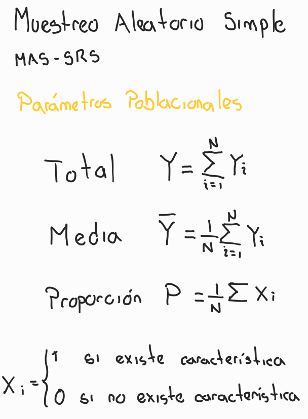

notas

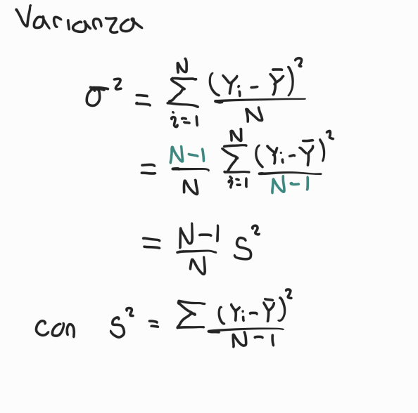

notas

### Estimadores de los parámetros poblacionales

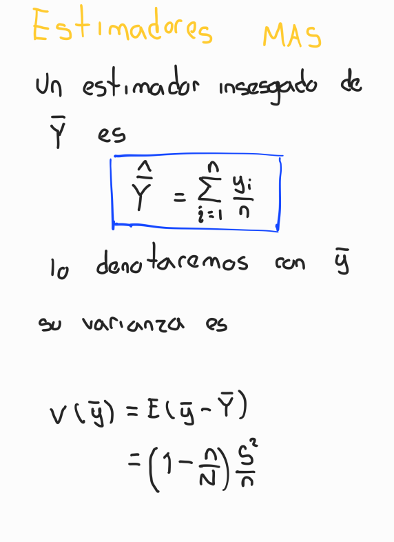

notas

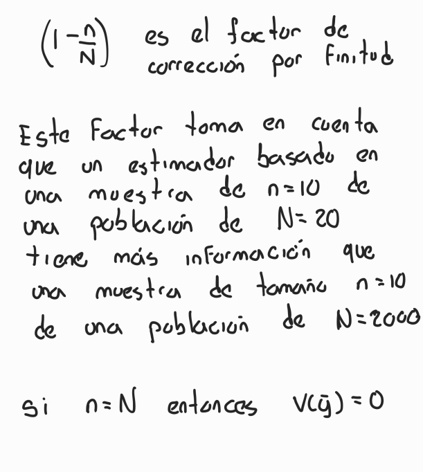

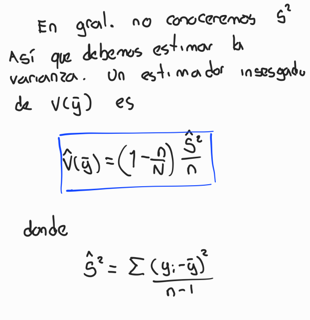

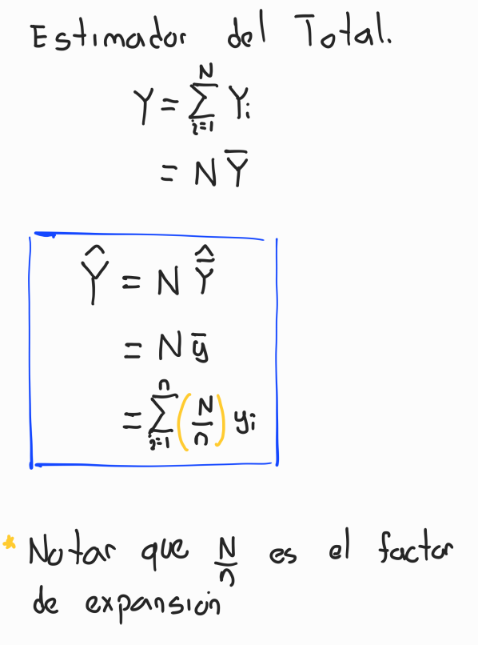

notas

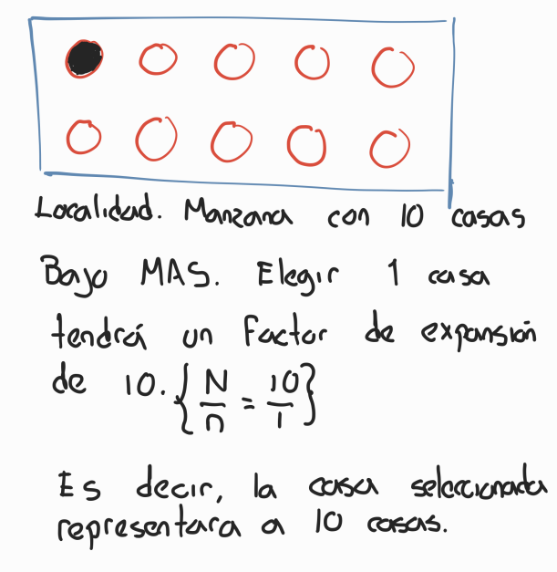

notas

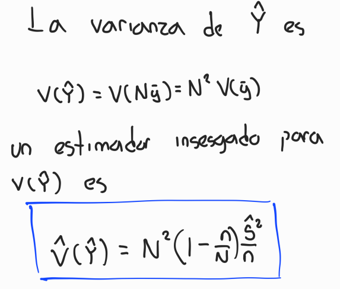

notas

**Ejemplos**

Los siguientes datos representan precios de valores de venta casas en Iowa tomados de la página de [Kaggle](https://www.kaggle.com/c/house-prices-advanced-regression-techniques).

**Importante**. Considerar los datos como nuestro universo.

1. Tomar una muestra aleatoria de tamaño 150 elementos (casas) y calcular el estimador de la media para el precio de las casas.
2. Tomar una muestra de 150 elementos (los primeros 150) y calcular el estimador de la media para el precio de las casas. Comparar con el estimador anterior y contra el valor promedio real (parámetro de la población).

Leer datos

```r
suppressMessages(library(tidyverse))
```

```r
precios <- read_csv("C:/Users/ipab24636/Documents/Acatlan/datos/HousePrices/HousePrices.csv") %>%
          arrange(desc(SalePrice))
glimpse(precios)
```

```
## Rows: 1,460
## Columns: 81
## $ Id            <dbl> 692, 1183, 1170, 899, 804, 1047, 441, 770, 179, 799, 186~
## $ MSSubClass    <dbl> 60, 60, 60, 20, 60, 60, 20, 60, 20, 60, 75, 20, 20, 60, ~
## $ MSZoning      <chr> "RL", "RL", "RL", "RL", "RL", "RL", "RL", "RL", "RL", "R~
## $ LotFrontage   <dbl> 104, 160, 118, 100, 107, 85, 105, 47, 63, 104, 90, NA, 1~
## $ LotArea       <dbl> 21535, 15623, 35760, 12919, 13891, 16056, 15431, 53504, ~
## $ Street        <chr> "Pave", "Pave", "Pave", "Pave", "Pave", "Pave", "Pave", ~
## $ Alley         <chr> NA, NA, NA, NA, NA, NA, NA, NA, NA, NA, NA, NA, NA, NA, ~
## $ LotShape      <chr> "IR1", "IR1", "IR1", "IR1", "Reg", "IR1", "Reg", "IR2", ~
## $ LandContour   <chr> "Lvl", "Lvl", "Lvl", "Lvl", "Lvl", "Lvl", "Lvl", "HLS", ~
## $ Utilities     <chr> "AllPub", "AllPub", "AllPub", "AllPub", "AllPub", "AllPu~
## $ LotConfig     <chr> "Corner", "Corner", "CulDSac", "Inside", "Inside", "Insi~
## $ LandSlope     <chr> "Gtl", "Gtl", "Gtl", "Gtl", "Gtl", "Gtl", "Gtl", "Mod", ~
## $ Neighborhood  <chr> "NoRidge", "NoRidge", "NoRidge", "NridgHt", "NridgHt", "~
```

[output cut: 68 more lines]

Considerando los datos anteriores como nuestra población. Veamos como se distribuye el precio de venta promedio de las casas.

```r
library(ggplot2)
```

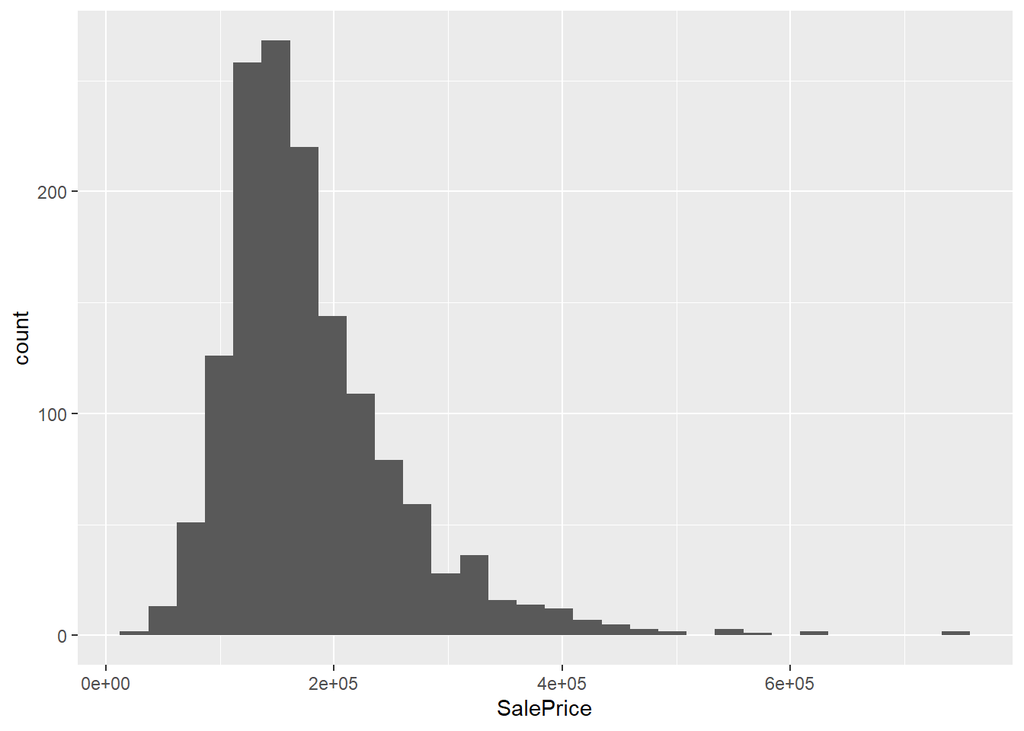

```r
ggplot(data = precios) +
  geom_histogram(mapping = aes(x = SalePrice))
```

Parámetro Poblacional, el promedio del precio de venta y su varianza

```r
# Promedio
precios %>% summarise(promedio = mean(SalePrice))
```

```
## # A tibble: 1 x 1
##   promedio
##      <dbl>
## 1  180921.
```

```r
# Varianza
precios %>% summarise(promedio = var(SalePrice))
```

```
## # A tibble: 1 x 1
##      promedio
##         <dbl>
## 1 6311111264.
```

```r
# desviación estándar
precios %>% summarise(promedio = sd(SalePrice))
```

```
## # A tibble: 1 x 1
##   promedio
##      <dbl>
## 1   79443.
```

Adicionalmente, con propositos descriptivos podemos generar un boxplot del precio. ¿Qué representan los elementos de este grafico, la caja, los puntos, los brazos (bigotes)?. ¿Qué utilidad se le puede dar?

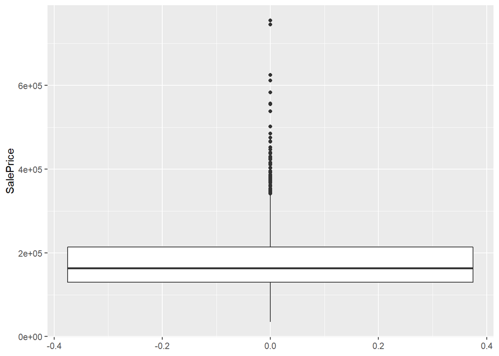

```r
ggplot(data = precios) +
  geom_boxplot(mapping = aes(y = SalePrice))
```

**muestra 1**

```r
set.seed(2021)
muestra1 <- sample_n(precios,150)
```

El estimador del promedio para el precio de venta es de esta muestra es

```r
muestra1 %>% summarise(promedio = mean(SalePrice))
```

```
## # A tibble: 1 x 1
##   promedio
##      <dbl>
## 1  174422.
```

```r
muestra1 %>% summarise(promedio = var(SalePrice))
```

```
## # A tibble: 1 x 1
##      promedio
##         <dbl>
## 1 5077639871.
```

```r
muestra1 %>% summarise(promedio = sd(SalePrice))
```

```
## # A tibble: 1 x 1
##   promedio
##      <dbl>
## 1   71258.
```

Así se ven los datos de esta muestra

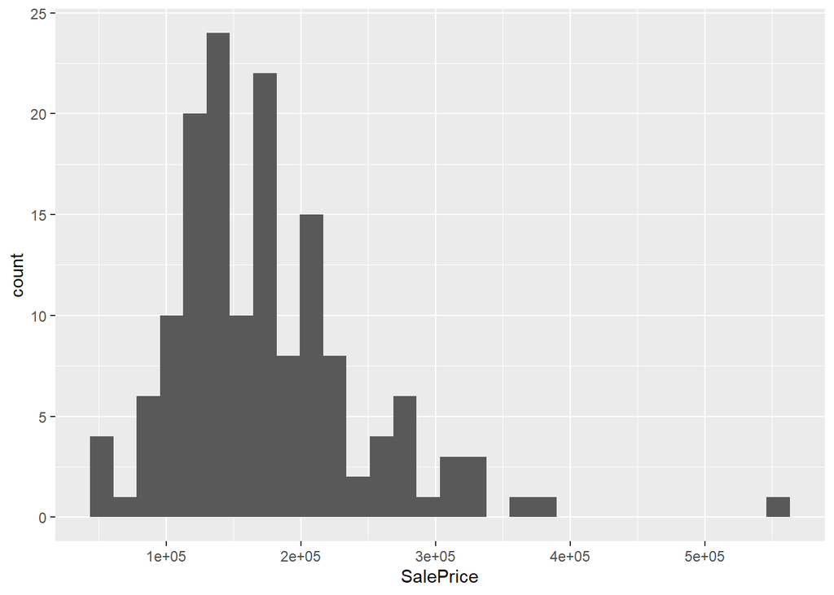

```r
  ggplot(data = muestra1) +
    geom_histogram(mapping = aes(x = SalePrice))
```

**muestra 2.** Las primeras 150 observaciones de la tabla ordenada de forma descendente por precio

```r
set.seed(2021)
muestra2 <- slice(precios,1:150)
```

El estimador de esta muestra es

```r
muestra2 %>% select(SalePrice) %>% pull() %>% mean()
```

```
## [1] 354885.9
```

Así se ven los datos de la segunda muestra

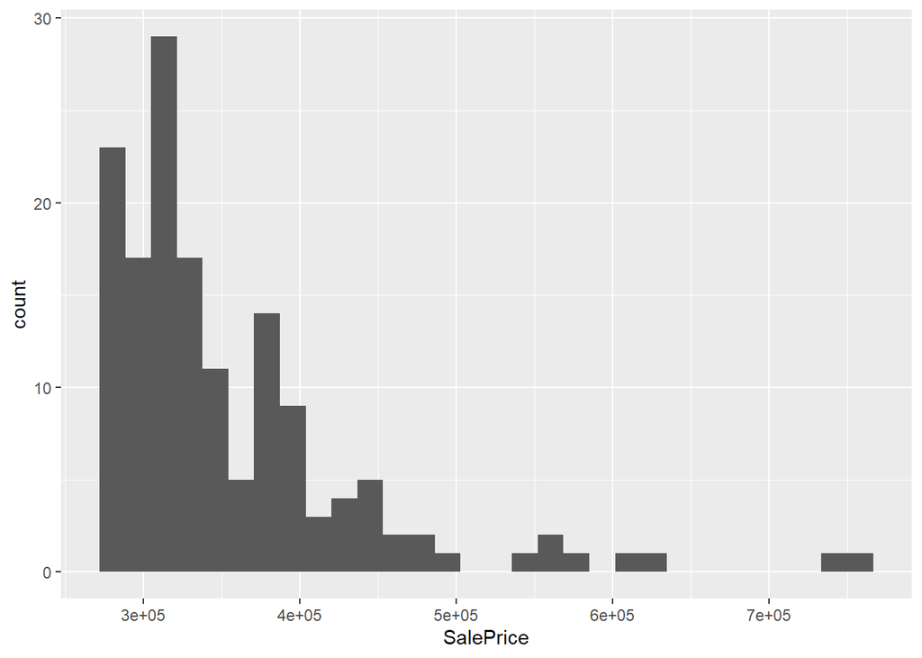

```r
  ggplot(data = muestra2) +
    geom_histogram(mapping = aes(x = SalePrice))
```

- ¿Puede ser la varianza de nuestro estimador más pequeña que la varianza de la variable de interés?.
- ¿Qué diferencia hay entre calcular la varianza de la variable de interés de los datos de la muestra y calcular el valor del estimador de la varianza?.

**Definición**. El **error estándar** es la desviación estandar de la estimación de la varianza de de nuestro estimador. Lo denotaremos por $ee$

Retomando el TLC y el error estándar (ee), utilicemos simulación para ejemplificar.

La media y la varianza de toda la población es (ya lo habiamos calculado previamente):

```r
precios %>% select(SalePrice) %>% pull() %>% mean()
```

```
## [1] 180921.2
```

```r
precios %>% select(SalePrice) %>% pull() %>% var()
```

```
## [1] 6311111264
```

Mediante simulación calcular el estimador de la media k veces y ver como se distribuye. Notar que hay muchas formas distintas de realizar esto, utilizaremos la siguiente

```r
library(purrr)
```

```r
calcular_estimador <- function(){
  muestra <- precios %>% sample_n(150)
  valor <- muestra %>% select(SalePrice) %>% pull() %>% mean()

  return(valor)
}
```

Ejecutar la función anterior que carece de parámetros

```r
calcular_estimador()
```

```
## [1] 174422.3
```

Ejecutar la función k veces y almacenar los resultados en un vector. Lo que nos dará son k estimaciones del precio medio de venta.

```r
valores_x_barra <- rerun(1000,calcular_estimador()) %>% unlist()
summary(valores_x_barra)
```

```
##    Min. 1st Qu.  Median    Mean 3rd Qu.    Max.
##  163637  176480  180553  180851  184947  203394
```

Recordar como se distribuía el precio de venta. La distribución de nuestro estimador se ve de la siguiente manera.

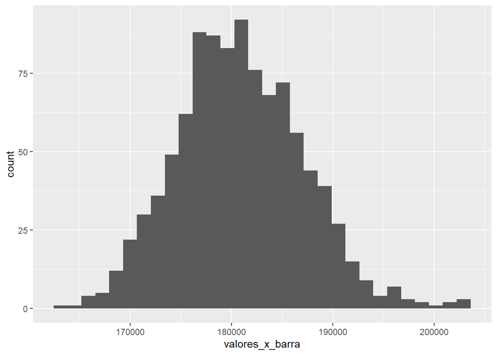

```r
ggplot() +
  geom_histogram(mapping = aes(x = valores_x_barra))
```

Nota. No confundir la definición formal de una función de distribución con la expresión usada arriba. Es usual que se diga la distribución de la variable para referirse a los valores en conjunto y la forma que toma su densidad (histograma).

Viendo la distribución del estimador ¿qué se les ocurre para crear un intervalo de confianza?, además de su primera opción, ¿qué otra opción pueden proponer teniendo los k valores de la distribución del estimador?.

No lo hemos definido aún pero, ¿es posible siempre construir un intervalo al 95% de confianza?

Notar que los valores de 1 muestra representan los valores de la población, es nuestro estimador el que por el TLC cambia su distribución.